# Question

A standard eight-sided [die](https://en.wikipedia.org/wiki/Dice) was rolled 500 times, and the results were organized into the [histogram](https://en.wikipedia.org/wiki/Histogram) shown below. In [dice notation](https://en.wikipedia.org/wiki/Dice_notation), we could say the results of 500d8 were plotted as a histogram. (Pedantic sidenote: it is common to interpret 500d8 as the SUM of 500 rolls, but we will interpret 500d8 as the LIST of 500 rolls and use $\sum 500\text{d}8$ as the sum of 500 rolls.)

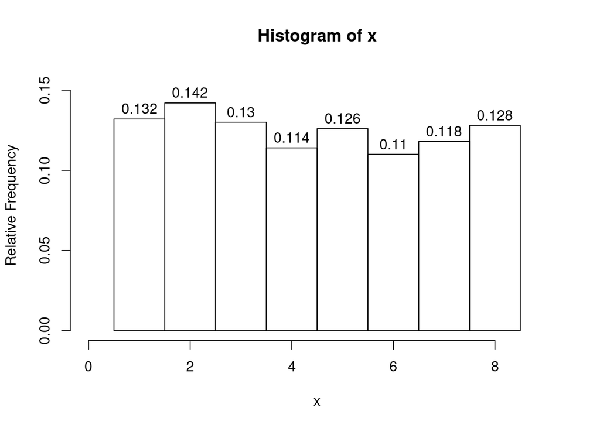

## Answerlist

- Evaluate $\text{prop}[\mathbf{x}<4.5]$.
- Evaluate $\text{prop}[\mathbf{x}>1.5]$.
- Evaluate $\text{prop}[|\mathbf{x}-4|<1.5]$.
- Evaluate $\text{prop}[|\mathbf{x}-3|>0.5]$.
- Evaluate half-integer boundary $b$ such that $\text{prop}[\mathbf{x}<b] = 0.404$.
- Evaluate half-integer boundary $b$ such that $\text{prop}[\mathbf{x}>b] = 0.246$.
- Evaluate integer radius $r$ such that $\text{prop}[|\mathbf{x}-6.5|<r] = 0.228$.
- Evaluate integer radius $r$ such that $\text{prop}[|\mathbf{x}-6.5|>r] = 0.772$.

# Solution

The first 4 questions involve adding up relative frequencies of the indicated intervals. The last 4 questions can be done by guessing and checking until something works.

You may also find it is helpful to determine frequencies (counts). You do this by multiplying each relative frequency by the total number of measurements.

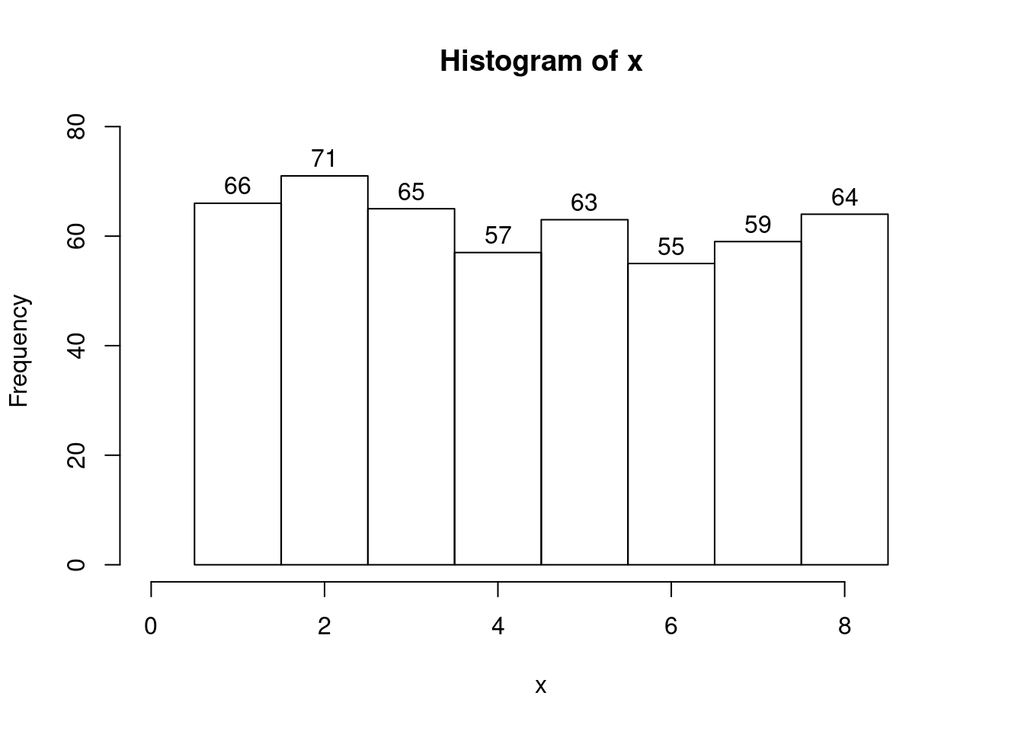

## Answerlist

- There are 259 measurements less than 4.5. So, $\text{prop}[\mathbf{x}<4.5]=\frac{259}{500}=0.518$.
- There are 434 measurements more than 1.5. So, $\text{prop}[\mathbf{x}>1.5]=\frac{434}{500}=0.868$.
- There are 185 measurements closer than 1.5 units from 4. So, $\text{prop}[|\mathbf{x}-4|<1.5]=\frac{185}{500}=0.37$.
- There are 435 measurements further than 0.5 units from 3. So, $\text{prop}[|\mathbf{x}-3|>0.5]=\frac{435}{500}=0.87$.
- First, convert the proportion into a count. $0.404\cdot500=202$. A boundary at $b=3.5$ has 202 measurements less than it. So, $\text{prop}[\mathbf{x}<3.5]=0.404$.
- First, convert the proportion into a count. $0.246\cdot500=123$. A boundary at $b=6.5$ has 123 measurements more than it. So, $\text{prop}[\mathbf{x}>6.5]=0.246$.
- An interval with radius $r=1$ around center 6.5 contains 114 measurements. So, $\text{prop}[|\mathbf{x}-6.5|<1]=0.228$.
- An interval with radius $r=1$ around center 6.5 excludes 386 measurements. So, $\text{prop}[|\mathbf{x}-6.5|>1]=0.772$.

# Meta-information

extype: cloze exclozetype: num|num|num|num|num|num|num|num exsolution: 0.518|0.868|0.37|0.87|3.5|6.5|1|1 exname: read_histogram_discrete_prop extol: 0.001 exextra[numwidth]: 999.99